# Regression 2

Vaneh Azaryan & Amirhossein Aminimanesh

2022

# 1 F statistic and Adjusted R-squared

## 1.1 Example 1

($x_1$=income, $x_2$=year, $y$=consumption)

```r
df1=data.frame(y=c(281.4,288.1,290,307.3,316,322.5,338.4,353.3,373.7,397.7,418.1,430.1,452.5,469.1,476.9),x1=c(309.3,316.1,318.8,333,340.3,350.5,367.2,381.2,408.1,434.8,458.9,477.5,499,513.5,533.4),x2=c(1:15))
model1=lm(y~x1+x2,data=df1)
summary(model1)
```

```
##
## Call:
## lm(formula = y ~ x1 + x2, data = df1)
##
## Residuals:
##    Min     1Q Median     3Q    Max
## -4.783 -1.237  0.789  1.284  4.603
##
## Coefficients:
##             Estimate Std. Error t value Pr(>|t|)
## (Intercept) 53.52305   13.05324   4.100  0.00147 **
## x1           0.72530    0.04885  14.847 4.37e-09 ***
## x2           2.75229    0.85068   3.235  0.00715 **
## ---
## Signif. codes:  0 '***' 0.001 '**' 0.01 '*' 0.05 '.' 0.1 ' ' 1
##
## Residual standard error: 2.543 on 12 degrees of freedom
## Multiple R-squared:  0.9988, Adjusted R-squared:  0.9986
## F-statistic:  5097 on 2 and 12 DF,  p-value: < 2.2e-16
```

As you can see above, the regression model would be $\hat{Y}=$ 53.5230548 $+$ 0.7253012 $X_1+$ 2.7522851 $X_2$. Also $R^2$ and adjusted $R^2$ are equal to 0.9988 and 0.9986, respectively. In addition, you can see the standard errors in the second column (titled Std. Error) and the t statistic for testing the significance of coefficients alongside its $P-value$ in the third (titled t value) and fourth (titled Pr(>|t|)) columns. Additionally, the F-statistic for testing $H_0=\hat{\beta}_1=\hat{\beta}_2=0$ hypothesis is 5097, with a p-value of 2.2e-16, indicating that $H_0$ is not accepted.

# 2 Marginal effect of an independent variable on a response variable (Y)

First we define the model with only one variable ($x_1$).

```r
model2=lm(y~x1,data=df1)
summary(model2)
```

```
##
## Call:
## lm(formula = y ~ x1, data = df1)
##
## Residuals:
##     Min      1Q  Median      3Q     Max
## -5.8306 -3.3120  0.9897  1.9386  4.6287
##
## Coefficients:
##             Estimate Std. Error t value Pr(>|t|)
## (Intercept) 12.90664    4.70173   2.745   0.0167 *
## x1           0.88081    0.01147  76.760   <2e-16 ***
## ---
## Signif. codes:  0 '***' 0.001 '**' 0.01 '*' 0.05 '.' 0.1 ' ' 1
##
## Residual standard error: 3.344 on 13 degrees of freedom
## Multiple R-squared:  0.9978, Adjusted R-squared:  0.9976
## F-statistic:  5892 on 1 and 13 DF,  p-value: < 2.2e-16
```

Then we compare two models (full model and model with only $x_1$).

```r
library(stargazer)

stargazer(model1, model2, type = "html")
```

|  | *Dependent variable:* |  |
| --- | --- | --- |
|  | y |  |
|  | (1) | (2) |
| x1 | 0.725*** | 0.881*** |
|  | (0.049) | (0.011) |
| x2 | 2.752*** |  |
|  | (0.851) |  |
| Constant | 53.523*** | 12.907** |
|  | (13.053) | (4.702) |
| Observations | 15 | 15 |
| R<sup>2</sup> | 0.999 | 0.998 |
| Adjusted R<sup>2</sup> | 0.999 | 0.998 |
| Residual Std. Error | 2.543 (df = 12) | 3.344 (df = 13) |
| F Statistic | 5,096.824*** (df = 2; 12) | 5,892.034*** (df = 1; 13) |
| *Note:* | p<0.1; p<0.05; p<0.01 |  |

Now we want to run the test to see if we can drop either of the variables from full model.

```r
#define intercept-only model
intercept_only <- lm(y ~ 1, data=df1)

#define model with all predictors
all <- lm(y ~ ., data=df1)

drop1(all, test="F")
```

```
## Single term deletions
##
## Model:
## y ~ x1 + x2
##        Df Sum of Sq     RSS    AIC F value    Pr(>F)
## <none>                77.63 30.658
## x1      1   1426.00 1503.63 73.114 220.442 4.369e-09 ***
## x2      1     67.71  145.34 38.065  10.468  0.007147 **
## ---
## Signif. codes:  0 '***' 0.001 '**' 0.01 '*' 0.05 '.' 0.1 ' ' 1
```

It can be seen that both terms are significant, meaning neither can be removed from the full model. Similarly, the Fisher statistic for testing if removing $x_2$ is significant is equal to **10.468** and the p-value is equal to 0.007147, showing that $x_2$ worth keeping in the model .

**Alternatively**

```r
anova(model1,model2)
```

```
## Analysis of Variance Table
##
## Model 1: y ~ x1 + x2
## Model 2: y ~ x1
##   Res.Df     RSS Df Sum of Sq      F   Pr(>F)
## 1     12  77.626
## 2     13 145.341 -1   -67.715 10.468 0.007147 **
## ---
## Signif. codes:  0 '***' 0.001 '**' 0.01 '*' 0.05 '.' 0.1 ' ' 1
```

You can see that the results are the same as described above.

# 3 Testing the equality of multiple coefficients

## 3.1 Method 1: (Paternoster et al (1998))

In this example we want to test the hypothesis $H_0: \beta_1 = \beta_2$ against otherwise. Thus, after extracting the intercept coefficient, we built the statistics as discussed in the handbook.

```r
bs <- coef(model1)[-1]
V <- vcov(model1)[-1, -1]
tibble::tibble(
  diff_estim = diff(bs),
  diff_SE = sqrt(V[1, 1] + V[2, 2] - 2 * V[1, 2]),
  t_stat = diff_estim / diff_SE,
  df = df.residual(model1),
  p_value = 2 * pt(abs(t_stat), df = df, lower.tail = FALSE)
)
```

```
## # A tibble: 1 × 5
##   diff_estim diff_SE t_stat    df p_value
##        <dbl>   <dbl>  <dbl> <int>   <dbl>
## 1       2.03   0.899   2.26    12  0.0436
```

$P-value$ is barely less than the assumed $\alpha$ ($0.05$), consequently not accepting the hypothesis of equality of the coefficients. However, this hypothesis could be accepted in $\alpha = 0.01$.

## 3.2 Method 2: By R package

The desired hypothesis could be more easily tested using $car$ package. The command $linearHypothesis$ does so. One just needs to specify the model and pass in the desired hypothesis in $c("\space" )$.

```r
library(car)
linearHypothesis(model1, c("x1 = x2" ))
```

```
## Linear hypothesis test
##
## Hypothesis:
## x1 - x2 = 0
##
## Model 1: restricted model
## Model 2: y ~ x1 + x2
##
##   Res.Df     RSS Df Sum of Sq      F  Pr(>F)
## 1     13 110.528
## 2     12  77.626  1    32.902 5.0862 0.04358 *
## ---
## Signif. codes:  0 '***' 0.001 '**' 0.01 '*' 0.05 '.' 0.1 ' ' 1
```

As can be seen, the $P-value$ obtained is equal to the one obtained when we built the statistic on our own.

# 4 Testing existence of a linear relationship between coefficients

As an example, we try testing the hypothesis that $H_0: \beta_1+\beta_2=1$. The procedure is as before.

```r
linearHypothesis(model1, c("x1 + x2= 1" ))
```

```
## Linear hypothesis test
##
## Hypothesis:
## x1  + x2 = 1
##
## Model 1: restricted model
## Model 2: y ~ x1 + x2
##
##   Res.Df     RSS Df Sum of Sq      F  Pr(>F)
## 1     13 139.260
## 2     12  77.626  1    61.634 9.5278 0.00942 **
## ---
## Signif. codes:  0 '***' 0.001 '**' 0.01 '*' 0.05 '.' 0.1 ' ' 1
```

In our example, we see that the addition of two coefficients is not equal to $1$ since the $P-value$ is quite small.

## 4.1 Example 2

We want to test the $H_0:\hat{\beta}_1+\hat{\beta}_2=1$ hypothesis on the following set of data in which $Y$ is amount of production, $X_1$ is labor, and $X_2$ is fund amount. We impose the variables in the model in a logarithmic scale.

```r
df2=data.frame(year=c(1958:1972),y=c(16607.7,17511.3,20171.2,20932.9,20406,20831.6,20806.3,26465.8,27403,28628.7,29904.5,27508.2,29035.5,29281.5,31535.8),x1=c(275.5,274.4,269.7,267,267.8,275,283,300.7,307.5,303.7,304.7,298.6,295.5,299,288.1),x2=c(17803.7,18096.8,18271.8,19167.3,19647.3,20803.5,22076.6,23445.2,24939,26713,29957.8,31585.9,33474.9,34821.8,41794.3))

model3=lm(log(y)~ log(x1) + log(x2),data=df2)
summary(model3)
```

```
##
## Call:
## lm(formula = log(y) ~ log(x1) + log(x2), data = df2)
##
## Residuals:
##      Min       1Q   Median       3Q      Max
## -0.14158 -0.04346  0.00857  0.05219  0.09924
##
## Coefficients:
##             Estimate Std. Error t value Pr(>|t|)
## (Intercept) -3.52255    2.34918  -1.499 0.159590
## log(x1)      1.49607    0.51769   2.890 0.013579 *
## log(x2)      0.50842    0.09786   5.195 0.000224 ***
## ---
## Signif. codes:  0 '***' 0.001 '**' 0.01 '*' 0.05 '.' 0.1 ' ' 1
##
## Residual standard error: 0.07175 on 12 degrees of freedom
## Multiple R-squared:  0.9014, Adjusted R-squared:  0.8849
## F-statistic: 54.83 on 2 and 12 DF,  p-value: 9.212e-07
```

```r
model4=lm(log(y/x1)~ log(x2/x1),data=df2)
summary(model4)
```

```
##
## Call:
## lm(formula = log(y/x1) ~ log(x2/x1), data = df2)
##
## Residuals:
##      Min       1Q   Median       3Q      Max
## -0.14727 -0.04918 -0.01429  0.06160  0.11226
##
## Coefficients:
##             Estimate Std. Error t value Pr(>|t|)
## (Intercept)  1.60546    0.40528   3.961  0.00163 **
## log(x2/x1)   0.63351    0.09093   6.967 9.81e-06 ***
## ---
## Signif. codes:  0 '***' 0.001 '**' 0.01 '*' 0.05 '.' 0.1 ' ' 1
##
## Residual standard error: 0.08175 on 13 degrees of freedom
## Multiple R-squared:  0.7888, Adjusted R-squared:  0.7725
## F-statistic: 48.54 on 1 and 13 DF,  p-value: 9.809e-06
```

```r
linearHypothesis(model3, c("log(x1) + log(x2) = 1" ))
```

```
## Linear hypothesis test
##
## Hypothesis:
## log(x1)  + log(x2) = 1
##
## Model 1: restricted model
## Model 2: log(y) ~ log(x1) + log(x2)
##
##   Res.Df      RSS Df Sum of Sq      F  Pr(>F)
## 1     13 0.086873
## 2     12 0.061770  1  0.025104 4.8768 0.04742 *
## ---
## Signif. codes:  0 '***' 0.001 '**' 0.01 '*' 0.05 '.' 0.1 ' ' 1
```

As can be seen, the F statistic is equal to 4.8768 and the p_value is 0.04742, which indicates that the $H_0$ hypothesis is not accepted.

## 4.2 Example 3

*Example 7.2 from Linear models in statistics*

```r
df4=data.frame(Observation_Number=c(1:12),y=c(2,3,2,7,6,8,10,7,8,12,11,14),x1=c(0,2,2,2,4,4,4,6,6,6,8,8),x2=c(2,6,7,5,9,8,7,10,11,9,15,13))
model5<- lm(y~ x1 + x2 , data=df4)
summary(model5)
```

```
##
## Call:
## lm(formula = y ~ x1 + x2, data = df4)
##
## Residuals:
##     Min      1Q  Median      3Q     Max
## -3.5915 -0.7157  0.1349  0.9562  2.0284
##
## Coefficients:
##             Estimate Std. Error t value Pr(>|t|)
## (Intercept)   5.3754     1.6605   3.237   0.0102 *
## x1            3.0118     0.6771   4.448   0.0016 **
## x2           -1.2855     0.4863  -2.643   0.0268 *
## ---
## Signif. codes:  0 '***' 0.001 '**' 0.01 '*' 0.05 '.' 0.1 ' ' 1
##
## Residual standard error: 1.682 on 9 degrees of freedom
## Multiple R-squared:  0.8457, Adjusted R-squared:  0.8114
## F-statistic: 24.66 on 2 and 9 DF,  p-value: 0.0002226
```

```r
model6<- lm(y~ x1  , data=df4)
summary(model6)
```

```
##
## Call:
## lm(formula = y ~ x1, data = df4)
##
## Residuals:
##     Min      1Q  Median      3Q     Max
## -2.6698 -1.5142 -0.4623  1.8774  2.9340
##
## Coefficients:
##             Estimate Std. Error t value Pr(>|t|)
## (Intercept)    1.859      1.256   1.479 0.169893
## x1             1.302      0.253   5.146 0.000434 ***
## ---
## Signif. codes:  0 '***' 0.001 '**' 0.01 '*' 0.05 '.' 0.1 ' ' 1
##
## Residual standard error: 2.127 on 10 degrees of freedom
## Multiple R-squared:  0.7259, Adjusted R-squared:  0.6985
## F-statistic: 26.48 on 1 and 10 DF,  p-value: 0.0004339
```

```r
model7<- lm(y~  x2 , data=df4)
summary(model7)
```

```
##
## Call:
## lm(formula = y ~ x2, data = df4)
##
## Residuals:
##    Min     1Q Median     3Q    Max
## -4.329 -1.726 -0.938  2.421  4.109
##
## Coefficients:
##             Estimate Std. Error t value Pr(>|t|)
## (Intercept)   0.8613     2.2300   0.386  0.70741
## x2            0.7810     0.2438   3.204  0.00943 **
## ---
## Signif. codes:  0 '***' 0.001 '**' 0.01 '*' 0.05 '.' 0.1 ' ' 1
##
## Residual standard error: 2.854 on 10 degrees of freedom
## Multiple R-squared:  0.5065, Adjusted R-squared:  0.4571
## F-statistic: 10.26 on 1 and 10 DF,  p-value: 0.009435
```

```r
coef5=round(coefficients(model5),2)
coef6=round(coefficients(model6),2)
coef7=round(coefficients(model7),2)
```

We obtain prediction equations for $y$ regressed on $x_1$ alone, on $x_2$ alone, and on both $x_1$ and $x_2$:  
$\hat{y}=$ 1.86 $+$ 1.3 $x_1$,  
$\hat{y}=$ 0.86 $+$ 0.78 $x_2$,  
$\hat{y}=$ 5.38 $+$ 3.01 $x_1-$ 1.29 $x_2$.

[figure not shown]

```r
# equation of the line :
eq = substitute("y = " ~a ~"+"~b~"*"~x[2], list(a = round(coef7[2],2) ,  b = round(coef7[1],2)))

# plot a scatter plot
plot(df4$x2,df4$y,
     main=eq,
     xlab='x2',ylab='y',pch = 19)
 title(sub ='Regression of y on x2 ignoring x1')
# plot a regression line
abline(model7,col='red')
```

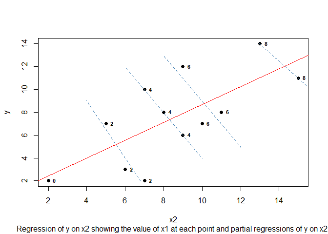

```r
# plot a scatter plot
plot(df4$x2,df4$y,
     xlab='x2',ylab='y',pch = 19)
text(df4$x2,df4$y,labels=df4$x1, cex= 0.7,pos=4,font=2)
title(sub ='Regression of y on x2 showing the value of x1 at each point and partial regressions of y on x2.')
# plot a regression line
abline(model7,col='red')
clip(min(subset(df4,df4$x1==2)$x2)-1, max(subset(df4,df4$x1==2)$x2)+1,min(df4$y) , max(df4$y))
abline(lm(y~  x2 , data=subset(df4,df4$x1==2)),col = 'steelblue', lwd = 1, lty = 2)
clip(min(subset(df4,df4$x1==4)$x2)-1, max(subset(df4,df4$x1==4)$x2)+1,min(df4$y) , max(df4$y))
abline(lm(y~  x2 , data=subset(df4,df4$x1==4)),col = 'steelblue', lwd = 1, lty = 2)
clip(min(subset(df4,df4$x1==6)$x2)-1, max(subset(df4,df4$x1==6)$x2)+1,min(df4$y) , max(df4$y))
abline(lm(y~  x2 , data=subset(df4,df4$x1==6)),col = 'steelblue', lwd = 1, lty = 2)
clip(min(subset(df4,df4$x1==8)$x2)-1, max(subset(df4,df4$x1==8)$x2)+1,min(df4$y) , max(df4$y))
abline(lm(y~  x2 , data=subset(df4,df4$x1==8)),col = 'steelblue', lwd = 1, lty = 2)
```

# 5 Outliers

To illustrate, we use R sample data (state.x77). This data set gives us information such as population size, average income, illiteracy rate, temperature, and murder rate for 50 states in USA.

```r
#https://towardsdatascience.com/how-to-detect-unusual-observations-on-your-regression-model-with-r-de0eaa38bc5b
library(car)
states <- as.data.frame(state.x77[,c('Murder', 'Population','Illiteracy', 'Income', 'Frost')])
knitr::kable(states)
```

|  | Murder | Population | Illiteracy | Income | Frost |
| --- | --- | --- | --- | --- | --- |
| Alabama | 15.1 | 3615 | 2.1 | 3624 | 20 |
| Alaska | 11.3 | 365 | 1.5 | 6315 | 152 |
| Arizona | 7.8 | 2212 | 1.8 | 4530 | 15 |
| Arkansas | 10.1 | 2110 | 1.9 | 3378 | 65 |
| California | 10.3 | 21198 | 1.1 | 5114 | 20 |
| Colorado | 6.8 | 2541 | 0.7 | 4884 | 166 |
| Connecticut | 3.1 | 3100 | 1.1 | 5348 | 139 |
| Delaware | 6.2 | 579 | 0.9 | 4809 | 103 |
| Florida | 10.7 | 8277 | 1.3 | 4815 | 11 |
| Georgia | 13.9 | 4931 | 2.0 | 4091 | 60 |
| Hawaii | 6.2 | 868 | 1.9 | 4963 | 0 |
| Idaho | 5.3 | 813 | 0.6 | 4119 | 126 |
| Illinois | 10.3 | 11197 | 0.9 | 5107 | 127 |
| Indiana | 7.1 | 5313 | 0.7 | 4458 | 122 |
| Iowa | 2.3 | 2861 | 0.5 | 4628 | 140 |
| Kansas | 4.5 | 2280 | 0.6 | 4669 | 114 |
| Kentucky | 10.6 | 3387 | 1.6 | 3712 | 95 |
| Louisiana | 13.2 | 3806 | 2.8 | 3545 | 12 |
| Maine | 2.7 | 1058 | 0.7 | 3694 | 161 |
| Maryland | 8.5 | 4122 | 0.9 | 5299 | 101 |
| Massachusetts | 3.3 | 5814 | 1.1 | 4755 | 103 |
| Michigan | 11.1 | 9111 | 0.9 | 4751 | 125 |
| Minnesota | 2.3 | 3921 | 0.6 | 4675 | 160 |
| Mississippi | 12.5 | 2341 | 2.4 | 3098 | 50 |
| Missouri | 9.3 | 4767 | 0.8 | 4254 | 108 |
| Montana | 5.0 | 746 | 0.6 | 4347 | 155 |
| Nebraska | 2.9 | 1544 | 0.6 | 4508 | 139 |
| Nevada | 11.5 | 590 | 0.5 | 5149 | 188 |
| New Hampshire | 3.3 | 812 | 0.7 | 4281 | 174 |
| New Jersey | 5.2 | 7333 | 1.1 | 5237 | 115 |
| New Mexico | 9.7 | 1144 | 2.2 | 3601 | 120 |
| New York | 10.9 | 18076 | 1.4 | 4903 | 82 |
| North Carolina | 11.1 | 5441 | 1.8 | 3875 | 80 |
| North Dakota | 1.4 | 637 | 0.8 | 5087 | 186 |
| Ohio | 7.4 | 10735 | 0.8 | 4561 | 124 |
| Oklahoma | 6.4 | 2715 | 1.1 | 3983 | 82 |
| Oregon | 4.2 | 2284 | 0.6 | 4660 | 44 |
| Pennsylvania | 6.1 | 11860 | 1.0 | 4449 | 126 |
| Rhode Island | 2.4 | 931 | 1.3 | 4558 | 127 |
| South Carolina | 11.6 | 2816 | 2.3 | 3635 | 65 |
| South Dakota | 1.7 | 681 | 0.5 | 4167 | 172 |
| Tennessee | 11.0 | 4173 | 1.7 | 3821 | 70 |
| Texas | 12.2 | 12237 | 2.2 | 4188 | 35 |
| Utah | 4.5 | 1203 | 0.6 | 4022 | 137 |
| Vermont | 5.5 | 472 | 0.6 | 3907 | 168 |
| Virginia | 9.5 | 4981 | 1.4 | 4701 | 85 |
| Washington | 4.3 | 3559 | 0.6 | 4864 | 32 |
| West Virginia | 6.7 | 1799 | 1.4 | 3617 | 100 |
| Wisconsin | 3.0 | 4589 | 0.7 | 4468 | 149 |
| Wyoming | 6.9 | 376 | 0.6 | 4566 | 173 |

```r
fit <- lm(Murder ~ Population + Illiteracy + Income + Frost, data=states)
summary(fit)
```

```
##
## Call:
## lm(formula = Murder ~ Population + Illiteracy + Income + Frost,
##     data = states)
##
## Residuals:
##     Min      1Q  Median      3Q     Max
## -4.7960 -1.6495 -0.0811  1.4815  7.6210
##
## Coefficients:
##              Estimate Std. Error t value Pr(>|t|)
## (Intercept) 1.235e+00  3.866e+00   0.319   0.7510
## Population  2.237e-04  9.052e-05   2.471   0.0173 *
## Illiteracy  4.143e+00  8.744e-01   4.738 2.19e-05 ***
## Income      6.442e-05  6.837e-04   0.094   0.9253
## Frost       5.813e-04  1.005e-02   0.058   0.9541
## ---
## Signif. codes:  0 '***' 0.001 '**' 0.01 '*' 0.05 '.' 0.1 ' ' 1
##
## Residual standard error: 2.535 on 45 degrees of freedom
## Multiple R-squared:  0.567,  Adjusted R-squared:  0.5285
## F-statistic: 14.73 on 4 and 45 DF,  p-value: 9.133e-08
```

We can start investigating outlier observations by using Q-Q plot. The Code below helps us plot and find potential outliers. Nevada (28th observation) and Rhode Island (39th observation) are states that are detected as potential outliers.

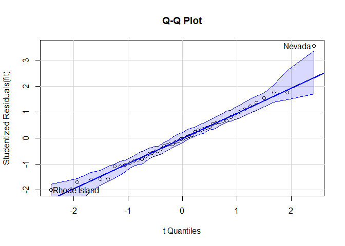

```
##       Nevada Rhode Island
##           28           39
```

```r
qqPlot(fit,labels=row.names(states), id.method='identify',
         simulate=TRUE, main='Q-Q Plot')
```

Applying outlierTest function would also help us to confirm if potential outliers are indeed outliers. The statistical test shows that Nevada undeniably is detected as an outlier with $P-value = 0.048$.

```r
outlierTest(fit)
```

```
##        rstudent unadjusted p-value Bonferroni p
## Nevada 3.542929         0.00095088     0.047544
```

Q-Q plot also confirms that Nevada has a large positive residual. It means our model underestimates the murder rate in this state. You can spot that the murder rate in Nevada is 11.5% while the model only predicts at 3.9%. We clearly understand that Nevada is indeed different compared to other states.

```r
knitr::kable(states['Nevada',])
```

|  | Murder | Population | Illiteracy | Income | Frost |
| --- | --- | --- | --- | --- | --- |
| Nevada | 11.5 | 590 | 0.5 | 5149 | 188 |

```r
knitr::kable(fitted(fit)['Nevada'], col.names = 'Predicted murder rate by the model')
```

|  | Predicted murder rate by the model |
| --- | --- |
| Nevada | 3.878958 |

Therefore, you can remove this observation and re-run the test to see if other outliers are present.

# 6 Influential Observations

## 6.1 Cook’s distance

Cook’s distance or Cook’s D is a commonly used estimate of the influence of a data point when performing a least-squares regression analysis. A general rule of thumb is that any point with a Cook’s Distance over $\frac{4}{n}$ or $\frac{4}{n-k-2}$ (where $n$ is the total number of data points and $k$ is number of parameters) is considered to be an outlier.

One can investigate the values of cook’s distance using the following code.

```r
cooks.distance(fit)
```

```
##        Alabama         Alaska        Arizona       Arkansas     California
##   6.353373e-02   4.480510e-01   1.411377e-02   2.317191e-04   8.052956e-03
##       Colorado    Connecticut       Delaware        Florida        Georgia
##   5.415332e-03   5.224719e-02   1.119829e-03   1.942168e-02   1.805694e-02
##         Hawaii          Idaho       Illinois        Indiana           Iowa
##   1.358197e-01   2.782621e-03   2.180966e-02   2.625579e-03   6.495825e-03
##         Kansas       Kentucky      Louisiana          Maine       Maryland
##   1.721812e-05   5.037790e-03   4.001973e-03   1.534931e-02   1.224012e-02
##  Massachusetts       Michigan      Minnesota    Mississippi       Missouri
##   1.527176e-02   2.783357e-02   1.150142e-02   2.054514e-03   1.596234e-02
##        Montana       Nebraska         Nevada  New Hampshire     New Jersey
##   1.004720e-03   3.557838e-03   2.099157e-01   4.402737e-03   1.641067e-02
##     New Mexico       New York North Carolina   North Dakota           Ohio
##   1.027124e-02   3.610642e-03   1.448887e-03   5.686889e-02   2.282029e-05
##       Oklahoma         Oregon   Pennsylvania   Rhode Island South Carolina
##   1.626635e-04   1.153433e-03   2.314645e-02   3.585896e-02   1.708758e-05
##   South Dakota      Tennessee          Texas           Utah        Vermont
##   1.244142e-02   3.533873e-03   7.686357e-03   7.407579e-05   5.770050e-03
##       Virginia     Washington  West Virginia      Wisconsin        Wyoming
##   1.071694e-03   3.302897e-03   2.166717e-03   9.093191e-03   1.545308e-02
```

The Code below provide a way to calculate the cut-off and plot Cook’s distance for each of our observation. The plot identifies Alaska, Hawaii, and Nevada as influential observations. Removing these 3 states will have a significant impact on the values of the intercept and slope in our regression model.

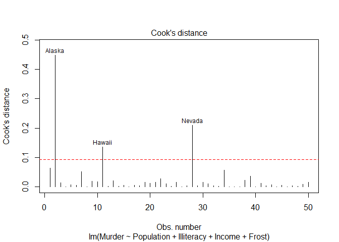

```r
cutoff <- 4/(nrow(states)-length(fit$coefficients)-2)
plot(fit, which=4, cook.levels=cutoff)
abline(h=cutoff, lty=2, col='red')
```

We need to highlight that the plot above is indeed helpful to identify influential observations, but it doesn’t give extra information about how these observations affect the model. That’s why Added Variable plots can be an option for us to dig more information.

## 6.2 Added Variable plots

Added variable plots works by plotting each predictor variable against the response variable and other predictors. It can be easily created using the $avPlots()$ command in $car$ package.

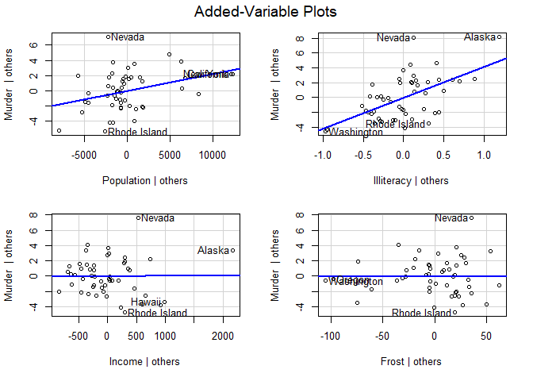

```r
library(car)
avPlots(fit, ask=FALSE, id.method='identify')
```

# 7 High-leverage points

Observations will be considered as high-leverage points if they resemble outliers when compared to other predictors. Strictly speaking, they have uncommon combination of predictor values while the response value has minor impact on determining leverage. You can compute the high leverage observation by looking at the ratio of number of parameters estimated in model to the sample size. If an observation has a ratio greater than $2-3$ times the average ratio, then the observation is considered as high-leverage points. We use the below function to identify high-leverage observations.

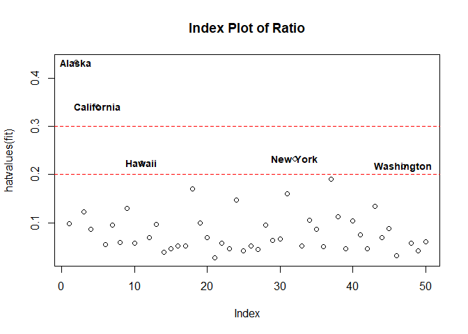

```r
highleverage <- function(fit) {
  p <- length(coefficients(fit))
  n <- length(fitted(fit))
  ratio <-p/n
  Index = as.numeric(which(hatvalues(fit)>2*ratio))
  hatvaluesleverage = hatvalues(fit)[Index]
  plot(hatvalues(fit), main='Index Plot of Ratio')
  abline(h=c(2,3)*ratio, col='red', lty=2)
  text(hatvaluesleverage ~ Index , labels=names(hatvaluesleverage),data=states, cex=0.9, font=2)
}
highleverage(fit)
```

The graph above indicates that Alaska and California have the highest ratio. It means these two states are quite unusual if we compare their predictor values to other states. Here is why:

- For Alaska, this state has a much higher income compared to other states, while having smaller population and lower temperature.
- For California, this state has a much bigger population than other states, while having higher income and higher temperature. Both of these states are indeed quite particular compared to the other 48 states. One thing to remember is that not all high-leverage observations are influential observations. It will depend on if they are outliers or not.

Now, we will incorporate all information from outlier, high-leverage, and influential observations into a single informative plot. InfluencePlot() is a very handy function to represent these unusual observation issues.

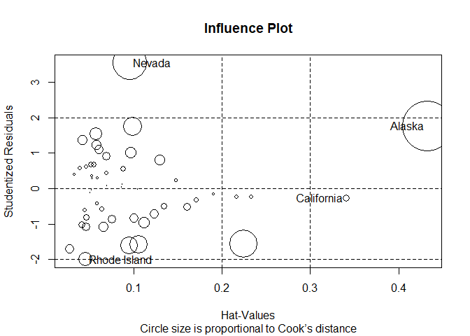

```
##                 StudRes        Hat       CookD
## Alaska        1.7536917 0.43247319 0.448050997
## California   -0.2761492 0.34087628 0.008052956
## Nevada        3.5429286 0.09508977 0.209915743
## Rhode Island -2.0001631 0.04562377 0.035858963
```

```r
library(car)
influencePlot(fit, id.method='identify', main='Influence Plot', sub='Circle size is proportional to Cook’s distance')
```

The graph above summarises our final verdict conveniently. Here it is:

- Nevada and Rhode island are Outliers.
- California, Washington, New York, and Hawaii are High-Leverage Observations
- Alaska is the Influential Observation

# 8 Centering

Centered predictors can be used in the regression analysis. In R, the function scale() can be used to center a variable around its mean. This function can be used in the regression function lm() directly. (Data used here is the first-year college GPA and four standardized tests are conducted before matriculation. It’s a data frame with 20 rows and 5 variables. “gpa.y”=first-year GPA, “sat.math.x1”=SAT math score, “sat.verb.x2”=SAT verbal score, “hs.math.x3”=high school math score, “hs.engl.x4”=high school English score.) First we look at the data and its structure, and built our model

```r
library('AICcmodavg')
data(gpa)
str(gpa)
```

```
## 'data.frame':    20 obs. of  5 variables:
##  $ gpa.y      : num  1.97 2.74 2.19 2.6 2.98 1.65 1.89 2.38 2.66 1.96 ...
##  $ sat.math.x1: num  321 718 358 403 640 237 270 418 443 359 ...
##  $ sat.verb.x2: num  247 436 578 447 563 342 472 356 327 385 ...
##  $ hs.math.x3 : num  2.3 3.8 2.98 3.58 3.38 1.48 1.67 3.73 3.09 1.54 ...
##  $ hs.engl.x4 : num  2.63 3.57 2.57 2.21 3.48 2.14 2.64 2.52 3.2 3.46 ...
```

```r
gpa.model<-lm(gpa.y~ sat.math.x1 + sat.verb.x2 +hs.math.x3, data=gpa)
summary(gpa.model)
```

```
##
## Call:
## lm(formula = gpa.y ~ sat.math.x1 + sat.verb.x2 + hs.math.x3,
##     data = gpa)
##
## Residuals:
##      Min       1Q   Median       3Q      Max
## -0.44589 -0.12849 -0.01274  0.10086  0.53291
##
## Coefficients:
##              Estimate Std. Error t value Pr(>|t|)
## (Intercept) 0.3342498  0.2587474   1.292 0.214776
## sat.math.x1 0.0021849  0.0004553   4.799 0.000197 ***
## sat.verb.x2 0.0013123  0.0005252   2.499 0.023738 *
## hs.math.x3  0.1798702  0.0876786   2.051 0.056964 .
## ---
## Signif. codes:  0 '***' 0.001 '**' 0.01 '*' 0.05 '.' 0.1 ' ' 1
##
## Residual standard error: 0.2621 on 16 degrees of freedom
## Multiple R-squared:  0.8504, Adjusted R-squared:  0.8223
## F-statistic: 30.31 on 3 and 16 DF,  p-value: 7.816e-07
```

```r
gpa.model.c<-lm(gpa.y~ scale(sat.math.x1,scale=F) + scale( sat.verb.x2,scale=F) + scale(hs.math.x3,scale=F), data=gpa)
summary(gpa.model.c)
```

```
##
## Call:
## lm(formula = gpa.y ~ scale(sat.math.x1, scale = F) + scale(sat.verb.x2,
##     scale = F) + scale(hs.math.x3, scale = F), data = gpa)
##
## Residuals:
##      Min       1Q   Median       3Q      Max
## -0.44589 -0.12849 -0.01274  0.10086  0.53291
##
## Coefficients:
##                                Estimate Std. Error t value Pr(>|t|)
## (Intercept)                   2.5930000  0.0586101  44.242  < 2e-16 ***
## scale(sat.math.x1, scale = F) 0.0021849  0.0004553   4.799 0.000197 ***
## scale(sat.verb.x2, scale = F) 0.0013123  0.0005252   2.499 0.023738 *
## scale(hs.math.x3, scale = F)  0.1798702  0.0876786   2.051 0.056964 .
## ---
## Signif. codes:  0 '***' 0.001 '**' 0.01 '*' 0.05 '.' 0.1 ' ' 1
##
## Residual standard error: 0.2621 on 16 degrees of freedom
## Multiple R-squared:  0.8504, Adjusted R-squared:  0.8223
## F-statistic: 30.31 on 3 and 16 DF,  p-value: 7.816e-07
```

Since when all three predictors are at their average values, the centered variables are 0. Therefore, the intercept can be interpreted as the predicted y value when the predictors are at their average values. Specifically, the college GAP would be 2.593 for a student with average SAT math score, average SAT verbal score, and average high school math score. Furthermore, we can see that centering does not change the regression coefficient estimates for the predictors.

# 9 An introduction on GLS

An overview of the models introduced:

$$models = \left\{
\begin{array}{ll}
lm =linear\space regression,\space normal\space errors,\space
constant\space variance \\
glm =generalized\space linear\space models,\space
non-normal\space errors,\space non-constant\space varince \\
gls =generalized\space least\space squares\space model,
\space\blacktriangleright correlated\space erros,\space
spatial/temporal\space paterns/trends\space(time\space series)
\end{array}
\right.$$
$lm$ or liner model have restrict assumptions like those mentioned above. Often our model doesn’t follow the desired assumptions. Thus we must use other model and methods which allow us to deviate from these assumptions that are not satisfied. $gls$ command in $nlme$ package is one way to do so. This function fits a linear model using generalized least squares. The errors are allowed to be correlated and/or have unequal variances. In the $gls$ command you have to specify the model; and you may also use the argument $correlation$ and specify the spatial pattern that exists in your data. If you do not specify any correlation and use the $gls$ command, it works the same as the usual $lm$ command, but shows some other statistics among which are goodness of fit measures like $AIC$, $BIC$ and $loglikelihood$. Moreover it give a summary of the standardized residuals which may be useful.

We use the previously introduced data, and fit both of the $lm$ and $gls$ to help us compare the results:

```r
knitr::kable(head(df1))
```

| y | x1 | x2 |
| --- | --- | --- |
| 281.4 | 309.3 | 1 |
| 288.1 | 316.1 | 2 |
| 290.0 | 318.8 | 3 |
| 307.3 | 333.0 | 4 |
| 316.0 | 340.3 | 5 |
| 322.5 | 350.5 | 6 |

Using the familiar $lm$ command:

```r
model1=lm(y~x1+x2,data=df1)
summary(model1)
```

```
##
## Call:
## lm(formula = y ~ x1 + x2, data = df1)
##
## Residuals:
##    Min     1Q Median     3Q    Max
## -4.783 -1.237  0.789  1.284  4.603
##
## Coefficients:
##             Estimate Std. Error t value Pr(>|t|)
## (Intercept) 53.52305   13.05324   4.100  0.00147 **
## x1           0.72530    0.04885  14.847 4.37e-09 ***
## x2           2.75229    0.85068   3.235  0.00715 **
## ---
## Signif. codes:  0 '***' 0.001 '**' 0.01 '*' 0.05 '.' 0.1 ' ' 1
##
## Residual standard error: 2.543 on 12 degrees of freedom
## Multiple R-squared:  0.9988, Adjusted R-squared:  0.9986
## F-statistic:  5097 on 2 and 12 DF,  p-value: < 2.2e-16
```

and using $gls$ command without specifying any correlation:

```r
library(nlme)
model1=gls(y~x1+x2,data=df1)
summary(model1)
```

```
## Generalized least squares fit by REML
##   Model: y ~ x1 + x2
##   Data: df1
##        AIC      BIC    logLik
##   80.70628 82.64591 -36.35314
##
## Coefficients:
##                Value Std.Error   t-value p-value
## (Intercept) 53.52305 13.053236  4.100367  0.0015
## x1           0.72530  0.048851 14.847293  0.0000
## x2           2.75229  0.850677  3.235406  0.0071
##
##  Correlation:
##    (Intr) x1
## x1 -0.994
## x2  0.962 -0.984
##
## Standardized residuals:
##        Min         Q1        Med         Q3        Max
## -1.8805658 -0.4864600  0.3102108  0.5046311  1.8096978
##
## Residual standard error: 2.54339
## Degrees of freedom: 15 total; 12 residual
```

As can be seen, the coefficients are the same.

There also exists another command named $Gls$ in the package $rms$ which does the same thing as $gls$ but is a slightly enhanced version.

# 10 Test for subset of coefficients being zero

Suppose we have a linear model $Y=β_0+β_1X_1+β_2X_2+β_3X_3+β_4X_4$ we want to test the hypothesis $H_0:β_1=β_2=β_4=0$. We should compare two models: one with the three coefficients in question and the other without them. The anova function will provide an F-statistic for that hypothesis (under the usual assumptions).

## 10.1 1st method: using $anova$ command (defining the full and the restricted models)

First we look at the data and its structure.

```r
#source:https://stackoverflow.com/questions/55551560/test-for-subset-of-coefficients-being-zero-in-r
data(gpa)
str(gpa)
```

```
## 'data.frame':    20 obs. of  5 variables:
##  $ gpa.y      : num  1.97 2.74 2.19 2.6 2.98 1.65 1.89 2.38 2.66 1.96 ...
##  $ sat.math.x1: num  321 718 358 403 640 237 270 418 443 359 ...
##  $ sat.verb.x2: num  247 436 578 447 563 342 472 356 327 385 ...
##  $ hs.math.x3 : num  2.3 3.8 2.98 3.58 3.38 1.48 1.67 3.73 3.09 1.54 ...
##  $ hs.engl.x4 : num  2.63 3.57 2.57 2.21 3.48 2.14 2.64 2.52 3.2 3.46 ...
```

First we fit the full model and look at its summary.

```r
model1 <- lm(formula = gpa.y ~ sat.math.x1+sat.verb.x2+hs.math.x3+hs.engl.x4, data = gpa)
summary(model1)
```

```
##
## Call:
## lm(formula = gpa.y ~ sat.math.x1 + sat.verb.x2 + hs.math.x3 +
##     hs.engl.x4, data = gpa)
##
## Residuals:
##      Min       1Q   Median       3Q      Max
## -0.44328 -0.12837  0.00257  0.13400  0.53900
##
## Coefficients:
##              Estimate Std. Error t value Pr(>|t|)
## (Intercept) 0.1615496  0.4375321   0.369  0.71712
## sat.math.x1 0.0020102  0.0005844   3.439  0.00365 **
## sat.verb.x2 0.0012522  0.0005515   2.270  0.03835 *
## hs.math.x3  0.1894402  0.0918680   2.062  0.05697 .
## hs.engl.x4  0.0875637  0.1764963   0.496  0.62700
## ---
## Signif. codes:  0 '***' 0.001 '**' 0.01 '*' 0.05 '.' 0.1 ' ' 1
##
## Residual standard error: 0.2685 on 15 degrees of freedom
## Multiple R-squared:  0.8528, Adjusted R-squared:  0.8135
## F-statistic: 21.72 on 4 and 15 DF,  p-value: 4.255e-06
```

And then, we create our restricted model. (The hypothesis being imposed)

```r
model2 <- lm(formula = gpa.y ~ hs.math.x3, data = gpa)
summary(model2)
```

```
##
## Call:
## lm(formula = gpa.y ~ hs.math.x3, data = gpa)
##
## Residuals:
##      Min       1Q   Median       3Q      Max
## -0.65675 -0.33747 -0.00996  0.24814  1.16212
##
## Coefficients:
##             Estimate Std. Error t value Pr(>|t|)
## (Intercept)   1.1473     0.3675   3.122 0.005887 **
## hs.math.x3    0.5066     0.1236   4.098 0.000675 ***
## ---
## Signif. codes:  0 '***' 0.001 '**' 0.01 '*' 0.05 '.' 0.1 ' ' 1
##
## Residual standard error: 0.4595 on 18 degrees of freedom
## Multiple R-squared:  0.4826, Adjusted R-squared:  0.4539
## F-statistic: 16.79 on 1 and 18 DF,  p-value: 0.0006754
```

Having done so, we use the $anova$ command to test the hypothesis as follows. Passing the models is enough for the function to work.

```r
anova(model1, model2)
```

```
## Analysis of Variance Table
##
## Model 1: gpa.y ~ sat.math.x1 + sat.verb.x2 + hs.math.x3 + hs.engl.x4
## Model 2: gpa.y ~ hs.math.x3
##   Res.Df    RSS Df Sum of Sq     F    Pr(>F)
## 1     15 1.0815
## 2     18 3.8004 -3   -2.7189 12.57 0.0002262 ***
## ---
## Signif. codes:  0 '***' 0.001 '**' 0.01 '*' 0.05 '.' 0.1 ' ' 1
```

Since the obtained $P-value$ is quite small, the $H_0$ hypothesis can’t be accepted.

## 10.2 2nd method: using $linearHypothesis$ command (checking multiple hypothesis at once)

It’s also possible to use the already familiar $linearHypothesis$ command to check several hypothesis all at once:

```r
linearHypothesis(model1,c( "sat.math.x1" , "sat.verb.x2" , "hs.engl.x4") , rep(0,3))
```

```
## Linear hypothesis test
##
## Hypothesis:
## sat.math.x1 = 0
## sat.verb.x2 = 0
## hs.engl.x4 = 0
##
## Model 1: restricted model
## Model 2: gpa.y ~ sat.math.x1 + sat.verb.x2 + hs.math.x3 + hs.engl.x4
##
##   Res.Df    RSS Df Sum of Sq     F    Pr(>F)
## 1     18 3.8004
## 2     15 1.0815  3    2.7189 12.57 0.0002262 ***
## ---
## Signif. codes:  0 '***' 0.001 '**' 0.01 '*' 0.05 '.' 0.1 ' ' 1
```

In the above command, one must specify the model fit, variables that wants to test and the values of the specified variables, passed in respectively. As expected, $P-value$ and test statistic with these two methods obtain the same results.

This command also allows you to test other hypothesis like $H_0: β_1=1;β_2=β_4=0$:

```r
linearHypothesis(model1,c( "sat.math.x1" , "sat.verb.x2" , "hs.engl.x4") , c(1,0,0))
```

```
## Linear hypothesis test
##
## Hypothesis:
## sat.math.x1 = 1
## sat.verb.x2 = 0
## hs.engl.x4 = 0
##
## Model 1: restricted model
## Model 2: gpa.y ~ sat.math.x1 + sat.verb.x2 + hs.math.x3 + hs.engl.x4
##
##   Res.Df    RSS Df Sum of Sq       F    Pr(>F)
## 1     18 358972
## 2     15      1  3    358970 1659597 < 2.2e-16 ***
## ---
## Signif. codes:  0 '***' 0.001 '**' 0.01 '*' 0.05 '.' 0.1 ' ' 1
```

# 11 Multicollinearity

Suppose we create a new variable that is a linear combination of $x_1$ and $x_2$ from example 1.

```r
df3=df1
df3$x3<- 100-df1$x1-df1$x2
model4<- lm(y~ x1 + x2 + x3 , data=df3)
 summary(model4)
```

```
##
## Call:
## lm(formula = y ~ x1 + x2 + x3, data = df3)
##
## Residuals:
##    Min     1Q Median     3Q    Max
## -4.783 -1.237  0.789  1.284  4.603
##
## Coefficients: (1 not defined because of singularities)
##             Estimate Std. Error t value Pr(>|t|)
## (Intercept) 53.52305   13.05324   4.100  0.00147 **
## x1           0.72530    0.04885  14.847 4.37e-09 ***
## x2           2.75229    0.85068   3.235  0.00715 **
## x3                NA         NA      NA       NA
## ---
## Signif. codes:  0 '***' 0.001 '**' 0.01 '*' 0.05 '.' 0.1 ' ' 1
##
## Residual standard error: 2.543 on 12 degrees of freedom
## Multiple R-squared:  0.9988, Adjusted R-squared:  0.9986
## F-statistic:  5097 on 2 and 12 DF,  p-value: < 2.2e-16
```

If we didn’t know which linear combination was causing the trouble, an eigen decomposition of $X^TX$ can help:

```r
x<-model.matrix(model4)
 e <- eigen(t(x) %*% x)
 knitr::kable( signif(e$values,3) , col.names = c('Significance of the eigen value in order of the summary output'))
```

| Significance of the eigen value in order of the summary output |
| --- |
| 4.06e+06 |
| 4.24e+03 |
| 6.63e+00 |
| 0.00e+00 |

## 11.1 Example 4

For this example we use the Boston data frame, which has 506 rows and 14 columns. The first few rows are shown below.

```r
#source:http://www.sthda.com/english/articles/39-regression-model-diagnostics/160-multicollinearity-essentials-and-vif-in-r/

library(tidyverse)
library(caret)
# Load the data
data("Boston", package = "MASS")
knitr::kable(head(Boston))
```

| crim | zn | indus | chas | nox | rm | age | dis | rad | tax | ptratio | black | lstat | medv |
| --- | --- | --- | --- | --- | --- | --- | --- | --- | --- | --- | --- | --- | --- |
| 0.00632 | 18 | 2.31 | 0 | 0.538 | 6.575 | 65.2 | 4.0900 | 1 | 296 | 15.3 | 396.90 | 4.98 | 24.0 |
| 0.02731 | 0 | 7.07 | 0 | 0.469 | 6.421 | 78.9 | 4.9671 | 2 | 242 | 17.8 | 396.90 | 9.14 | 21.6 |
| 0.02729 | 0 | 7.07 | 0 | 0.469 | 7.185 | 61.1 | 4.9671 | 2 | 242 | 17.8 | 392.83 | 4.03 | 34.7 |
| 0.03237 | 0 | 2.18 | 0 | 0.458 | 6.998 | 45.8 | 6.0622 | 3 | 222 | 18.7 | 394.63 | 2.94 | 33.4 |
| 0.06905 | 0 | 2.18 | 0 | 0.458 | 7.147 | 54.2 | 6.0622 | 3 | 222 | 18.7 | 396.90 | 5.33 | 36.2 |
| 0.02985 | 0 | 2.18 | 0 | 0.458 | 6.430 | 58.7 | 6.0622 | 3 | 222 | 18.7 | 394.12 | 5.21 | 28.7 |

```r
# Split the data into training and test set
set.seed(123)
training.samples <- Boston$medv %>%
  createDataPartition(p = 0.8, list = FALSE)
train.data  <- Boston[training.samples, ]
test.data <- Boston[-training.samples, ]
# Build the model
model1 <- lm(medv ~., data = train.data)
# Make predictions
predictions <- model1 %>% predict(test.data)
# Model performance
knitr::kable(data.frame(RMSE(predictions, test.data$medv),R2(predictions, test.data$medv)) , col.names = c('RMSE' , '$R^2$'))
```

| RMSE | $R^2$ |
| --- | --- |
| 4.588948 | 0.761126 |

```r
#Detecting multicollinearity
knitr::kable(car::vif(model1) , col.names = c('$VIF$'))
```

|  | $VIF$ |
| --- | --- |
| crim | 1.844585 |
| zn | 2.323334 |
| indus | 3.956419 |
| chas | 1.066866 |
| nox | 4.447852 |
| rm | 1.911905 |
| age | 3.213786 |
| dis | 4.065420 |
| rad | 8.152643 |
| tax | 9.660128 |
| ptratio | 1.851645 |
| black | 1.364539 |
| lstat | 3.131835 |

## 11.2 Dealing with multicollinearity

After identifying which variable has caused the collinearity problem, one can remove that variable and re-perform the analysis.

```r
# Build a model excluding the tax variable
model2 <- lm(medv ~. -tax, data = train.data)
# Make predictions
predictions <- model2 %>% predict(test.data)
# Model performance
knitr::kable(data.frame(
  RMSE = RMSE(predictions, test.data$medv),
  R2 = R2(predictions, test.data$medv)
) , col.names = c('RMSE' , '$R^2$'))
```

| RMSE | $R^2$ |
| --- | --- |
| 4.644396 | 0.7558647 |

It can be seen that removing the $tax$ variable does not affect the model performance metrics so much.

# 12 The Durbin Watson (DW) statistic

Durbin watson statistic is a test for autocorrelation in the residuals from a statistical model or regression analysis. The Durbin-Watson statistic will always have a value ranging between 0 and 4. A value of 2.0 indicates there is no autocorrelation detected in the sample. Here the $H_0: There\space is\space no\space correlation\space among\space the\space residuals$ and $H_1: The\space residuals\space are\space autocorrelated$.

```r
durbinWatsonTest(lm(fconvict ~ tfr + partic + degrees + mconvict, data=Hartnagel))
```

```
##  lag Autocorrelation D-W Statistic p-value
##    1        0.688345     0.6168636       0
##  Alternative hypothesis: rho != 0
```

# 13 Model Diagnostics

We want to fit a multiple linear regression on the MTCARS data.The data was extracted from the 1974 Motor Trend US magazine, and comprises fuel consumption and 10 aspects of automobile design and performance for 32 automobiles (1973–74 models). It’s a data frame with 32 observations on 11(numeric) variables.

First we load the package including the dataset and look at the first 6 observations.

```r
#source:https://www.statmethods.net/stats/rdiagnostics.html

library(car)
knitr::kable(head(mtcars))
```

|  | mpg | cyl | disp | hp | drat | wt | qsec | vs | am | gear | carb |
| --- | --- | --- | --- | --- | --- | --- | --- | --- | --- | --- | --- |
| Mazda RX4 | 21.0 | 6 | 160 | 110 | 3.90 | 2.620 | 16.46 | 0 | 1 | 4 | 4 |
| Mazda RX4 Wag | 21.0 | 6 | 160 | 110 | 3.90 | 2.875 | 17.02 | 0 | 1 | 4 | 4 |
| Datsun 710 | 22.8 | 4 | 108 | 93 | 3.85 | 2.320 | 18.61 | 1 | 1 | 4 | 1 |
| Hornet 4 Drive | 21.4 | 6 | 258 | 110 | 3.08 | 3.215 | 19.44 | 1 | 0 | 3 | 1 |
| Hornet Sportabout | 18.7 | 8 | 360 | 175 | 3.15 | 3.440 | 17.02 | 0 | 0 | 3 | 2 |
| Valiant | 18.1 | 6 | 225 | 105 | 2.76 | 3.460 | 20.22 | 1 | 0 | 3 | 1 |

Next we fit our model with response variable $mpg$ and predictors $disp$,$hp$,$wt$ and $drat$. We also plot the Q-Q plot to visually investigate if any of these observations looks extreme compared to the others.

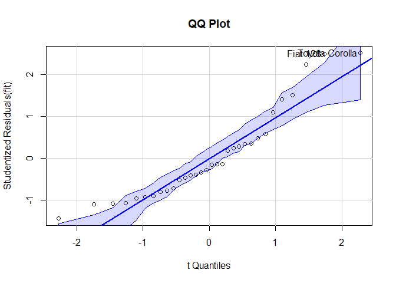

```
##       Fiat 128 Toyota Corolla
##             18             20
```

```r
fit <- lm(mpg~disp+hp+wt+drat, data=mtcars)
qqPlot(fit, main="QQ Plot") #qq plot for studentized resid
```

The plot reveals that two of these observations named $Fiat 128$ and $Toyota corolla$ may be outliers. To statistically confirm the above statement, official statistical tests are need. The command $outlierTest$ would do so.

```r
# Assessing Outliers
outlierTest(fit) # Bonferonni p-value for most extreme obs
```

```
## No Studentized residuals with Bonferroni p < 0.05
## Largest |rstudent|:
##                rstudent unadjusted p-value Bonferroni p
## Toyota Corolla  2.51597            0.01838      0.58816
```

One can also look at the add-variable plot. Added variable plots works by plotting each predictor variable against the response variable and other predictors. (partial regression)

The command $leveragePlots( model )$ also does the similar thing. It’s just a generalization of added-variable plots to multiple-df terms in a linear model. When a term has just 1 df, the leverage plot is a re-scaled version of the usual added-variable (partial-regression) plot.

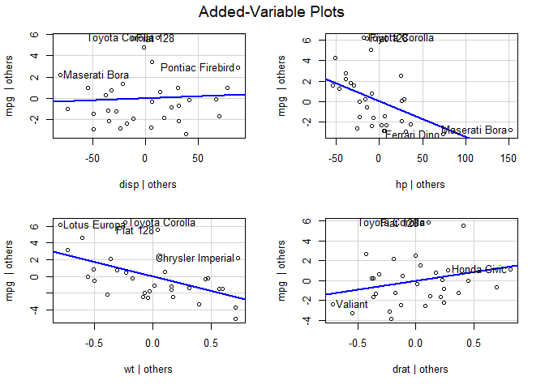

```r
# Influential Observations
# added variable plots
avPlots(fit)
```

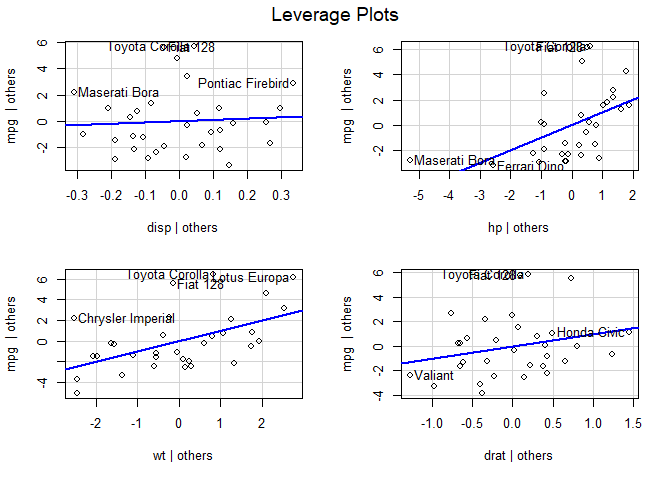

```r
leveragePlots(fit) # leverage plots
```

Cook’s distance shows the influence of each observation on the fitted response values.

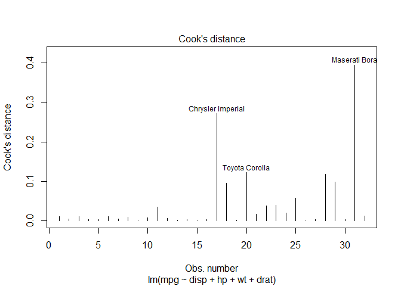

```r
# Cook's D plot
# identify D values > 4/(n-k-1)
cutoff <- 4/((nrow(mtcars)-length(fit$coefficients)-2))
plot(fit, which=4, cook.levels=cutoff)
```

Putting all the above mentioned information about outlier and influential observations together in one single plot can be done using the following command:

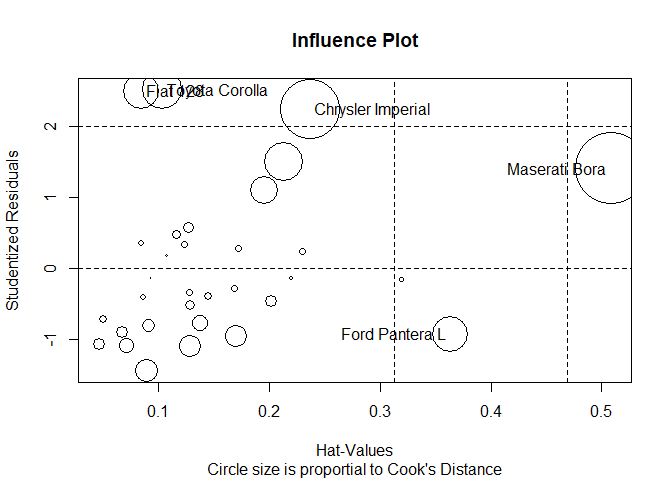

```
##                      StudRes        Hat      CookD
## Chrysler Imperial  2.2446894 0.23636908 0.27133817
## Fiat 128           2.4958292 0.08435766 0.09615527
## Toyota Corolla     2.5159696 0.10355543 0.12213690
## Ford Pantera L    -0.9300234 0.36351495 0.09929551
## Maserati Bora      1.4051504 0.50833966 0.39406393
```

```r
# Influence Plot
influencePlot(fit, id.method="identify", main="Influence Plot", sub="Circle size is proportial to Cook's Distance" )
```

Next, we check normality assumption of the residuals. One of the first thing to do is to look at the Q-Q plot of residuals. (already shown for this example) One should also plot the histogram of the residuals. It must look like the histogram of normal distribution to satisfy linear regression assumptions. We plot the histogram for studentized residuals here:

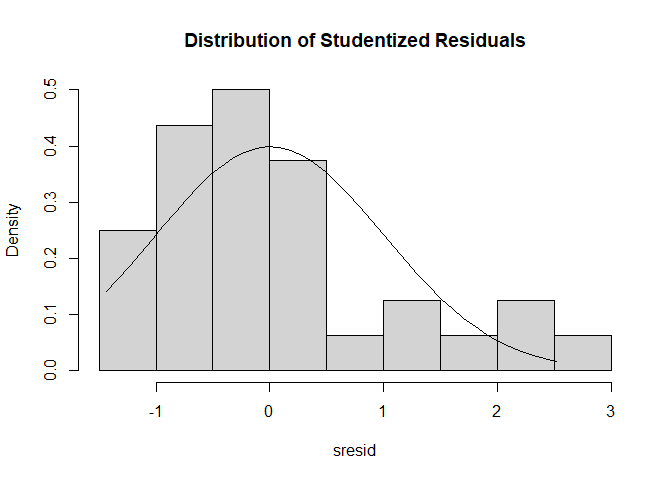

```r
# distribution of studentized residuals
library(MASS)
sresid <- studres(fit)
hist(sresid, freq=FALSE,
   main="Distribution of Studentized Residuals")
xfit<-seq(min(sresid),max(sresid),length=40)
yfit<-dnorm(xfit)
lines(xfit, yfit)
```

As can be seen, it’s skewed to the right; showing deviation from normality assumption of the residuals.

Another assumption to satisfy is that the error variance should be constant. It means in the plot of $Residulas vs. Fitted value$ no trend should be seen. As always the $H_0$ hypothesis represents an equality; here the $H_0$ for our desired test mean that the error variance is constant against the alternative that the error variance changes with the level of the response (fitted values), or with a linear combination of predictors. The $ncvTest$ command helps us test our hypothesis.

```r
#Non-constant Error Variance
# Evaluate homoscedasticity
# non-constant error variance test
ncvTest(fit)
```

```
## Non-constant Variance Score Test
## Variance formula: ~ fitted.values
## Chisquare = 1.429672, Df = 1, p = 0.23182
```

Since the $P-value$ is above the confidence level of $\alpha=0.05$, thus the $H_0$ is not rejected; meaning that the assumption of constant error variance is satisfied.

Also the above mentioned plot of $Residulas vs. Fitted value$ could be plotted using the following $spreadLevelPlot$ command:

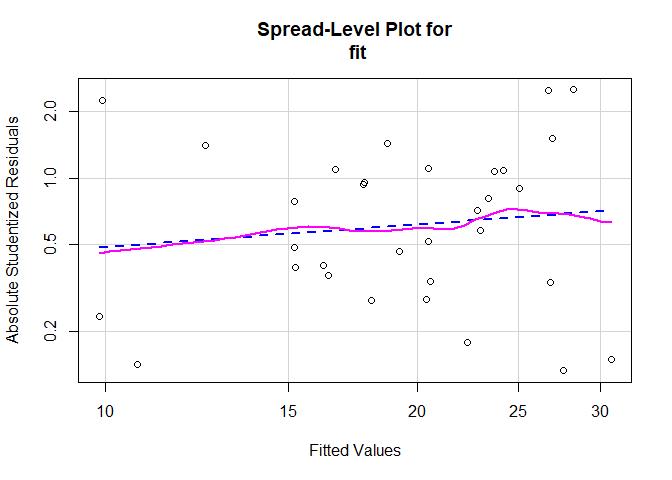

```
##
## Suggested power transformation:  0.6616338
```

```r
# plot studentized residuals vs. fitted values
spreadLevelPlot(fit)
```

It also suggests that the power transformation of $0.6616338$ could be imposed on our data to get better results about our assumptions.

When analyzing the data and fitting linear models, there shouldn’t be any Multi-collinearity between predictors. $VIF$ is a measure of evaluating collinearity. Large values are an indicator that care should be taken when fitting the model on the current predictors

```r
#Multi-collinearity
# Evaluate Collinearity
vif(fit) # variance inflation factors
```

```
##     disp       hp       wt     drat
## 8.209402 2.894373 5.096601 2.279547
```

```r
sqrt(vif(fit)) > 2 # problem?
```

```
##  disp    hp    wt  drat
##  TRUE FALSE  TRUE FALSE
```

Here the result suggests that $disp$ has a relatively high $VIF$ and more investigates should be done on this predictor.

Next we check if each of the predictors have a linear relation with the response variable given other predictors. Component residual plots, an extension of partial residual plots, are a good way to see if the predictors have a linear relationship to the dependent variable. A partial residual plot essentially attempts to model the residuals of one predictor against the dependent variable.

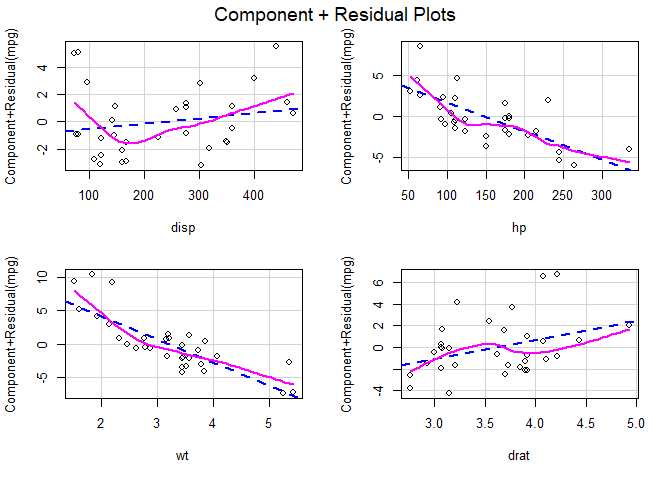

```r
#Nonlinearity
# Evaluate Nonlinearity
# component + residual plot
crPlots(fit)
```

The above command shows that each of the predictors almost have a linear relation with the response variable given other predictors. (The blue line which is a linear fit on the data almost follows the pink line which is the true trend)

Also $ceresPlots$ command does the similar thing. Ceres plots are a generalization of component residual (partial residual) plots that are less prone to leakage of nonlinearity among the predictors.

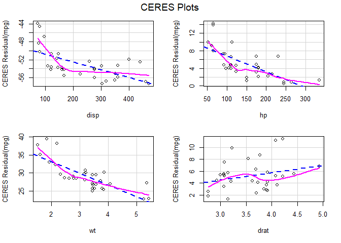

```r
# Ceres plots
ceresPlots(fit)
```

The results are almost consistence with the results obtains using $crPlots$

Next we check the Durbin Watson test for the autocorrelation in the residuals.

```r
#Non-independence of Errors
# Test for Autocorrelated Errors
durbinWatsonTest(fit)
```

```
##  lag Autocorrelation D-W Statistic p-value
##    1        0.100862      1.735915   0.324
##  Alternative hypothesis: rho != 0
```

As the $P-value$ shows, the residuals are not autocorrelated.

In the end, we fit the model using $gvlma$ commmand in the package of the same name. It performs a global validation of linear model assumptions as well separate evaluations of skewness, kurtosis, and heteroscedasticity

```r
#The gvlma( ) function in the gvlma package, performs a global validation of linear model assumptions as well separate evaluations of skewness, kurtosis, and heteroscedasticity.

# Global test of model assumptions
library(gvlma)
gvmodel <- gvlma(fit)
summary(gvmodel)
```

```
##
## Call:
## lm(formula = mpg ~ disp + hp + wt + drat, data = mtcars)
##
## Residuals:
##     Min      1Q  Median      3Q     Max
## -3.5077 -1.9052 -0.5057  0.9821  5.6883
##
## Coefficients:
##              Estimate Std. Error t value Pr(>|t|)
## (Intercept) 29.148738   6.293588   4.631  8.2e-05 ***
## disp         0.003815   0.010805   0.353  0.72675
## hp          -0.034784   0.011597  -2.999  0.00576 **
## wt          -3.479668   1.078371  -3.227  0.00327 **
## drat         1.768049   1.319779   1.340  0.19153
## ---
## Signif. codes:  0 '***' 0.001 '**' 0.01 '*' 0.05 '.' 0.1 ' ' 1
##
## Residual standard error: 2.602 on 27 degrees of freedom
## Multiple R-squared:  0.8376, Adjusted R-squared:  0.8136
## F-statistic: 34.82 on 4 and 27 DF,  p-value: 2.704e-10
##
##
## ASSESSMENT OF THE LINEAR MODEL ASSUMPTIONS
## USING THE GLOBAL TEST ON 4 DEGREES-OF-FREEDOM:
## Level of Significance =  0.05
##
## Call:
##  gvlma(x = fit)
##
##                       Value  p-value                   Decision
## Global Stat        13.93816 0.007495 Assumptions NOT satisfied!
## Skewness            4.31310 0.037820 Assumptions NOT satisfied!
## Kurtosis            0.01378 0.906542    Assumptions acceptable.
## Link Function       8.71658 0.003153 Assumptions NOT satisfied!
## Heteroscedasticity  0.89470 0.344207    Assumptions acceptable.
```

1. Global Stat- Are the relationships between your X predictors and Y roughly linear?. Rejection of the null (p < .05) indicates a non-linear relationship between one or more of your X’s and Y
2. Skewness - Is your distribution skewed positively or negatively, necessitating a transformation to meet the assumption of normality? Rejection of the null (p < .05) indicates that you should likely transform your data.
3. Kurtosis- Is your distribution kurtotic (highly peaked or very shallowly peaked), necessitating a transformation to meet the assumption of normality? Rejection of the null (p < .05) indicates that you should likely transform your data.
4. Link Function- Is your dependent variable truly continuous, or categorical? Rejection of the null (p < .05) indicates that you should use an alternative form of the generalized linear model (e.g. logistic or binomial regression).
5. Heteroscedasticity- Is the variance of your model residuals constant across the range of X (assumption of homoscedastiity)? Rejection of the null (p < .05) indicates that your residuals are heteroscedastic, and thus non-constant across the range of X. Your model is better/worse at predicting for certain ranges of your X scales.

The results obtained show the coefficient of the predictors in the model alongside their $P-value$ and other statistics. Also some of the model assumptions are discussed in the last part of the output. The results about skewness and heteroscedasticity were already obtained for this example and consistant we the results obtained from this command.

# 14 Dummy Variables

## 14.1 Example 5

(D=gender, y=salary)

```r
df5=data.frame(y=c(22,19,18,21.5,18.5,21,17,17.5,21.2),D=c(1,0,0,1,0,1,0,0,1))
df5$D=as.factor(df5$D)
model8=lm(y~D,data=df5)
summary(model8)
```

```
##
## Call:
## lm(formula = y ~ D, data = df5)
##
## Residuals:
##    Min     1Q Median     3Q    Max
## -1.000 -0.425  0.000  0.500  1.000
##
## Coefficients:
##             Estimate Std. Error t value Pr(>|t|)
## (Intercept)  18.0000     0.2960  60.801 8.55e-11 ***
## D1            3.4250     0.4441   7.713 0.000115 ***
## ---
## Signif. codes:  0 '***' 0.001 '**' 0.01 '*' 0.05 '.' 0.1 ' ' 1
##
## Residual standard error: 0.662 on 7 degrees of freedom
## Multiple R-squared:  0.8947, Adjusted R-squared:  0.8797
## F-statistic: 59.49 on 1 and 7 DF,  p-value: 0.000115
```

```r
library(ggplot2)
library(tidyverse)
Y = c(22 , 19 , 18 , 21.5 , 18.5 , 21 , 17 , 17.5 , 21.2 )
Dummy = as.factor(c("male" , "female" , "female" , "male" , "female" ,  "male" , "female" , "female" , "male" ))
lm(Y~Dummy)
```

```
##
## Call:
## lm(formula = Y ~ Dummy)
##
## Coefficients:
## (Intercept)    Dummymale
##      18.000        3.425
```

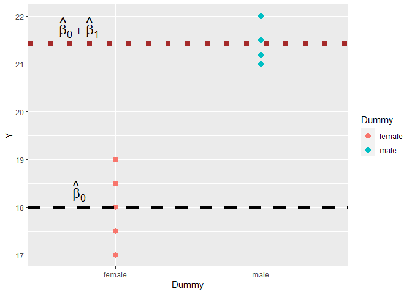

```r
ggplot(data = data.frame(Y, Dummy), aes(x = Dummy , y = Y , col = Dummy)) +
  geom_point(size = 3) +
  geom_hline(yintercept = coef(lm(Y~Dummy))[1] , linetype="dashed", color = "black" , size=2) +
  geom_hline(yintercept = coef(lm(Y~Dummy))[1] + coef(lm(Y~Dummy))[2] , linetype="dotted", color = "brown" , size=3) +
  annotate("text", x = 0.75, y = coef(lm(Y~Dummy))[1] + 0.35, parse = TRUE,
           label = "hat(beta)[0]" , size = 6 ) +
  annotate("text", x = 0.75, y = coef(lm(Y~Dummy))[1] + coef(lm(Y~Dummy))[2] + 0.35, parse = TRUE,
           label = "hat(beta)[0]+hat(beta)[1]" , size = 6)
```

## 14.2 Categorical variables with more than two levels

## 14.3 Example 6

Dataset used for this example is the 2008-09 nine-month academic salary for Assistant Professors, Associate Professors and Professors in a college in the U.S. The data were collected as part of the on-going effort of the college’s administration to monitor salary differences between male and female faculty members. It’s a data frame with 397 observations on the 6 variables.The first few rows are shown below.

```r
#http://www.sthda.com/english/articles/40-regression-analysis/163-regression-with-categorical-variables-dummy-coding-essentials-in-r/
# Load the data
data("Salaries", package = "car")
# Inspect the data
library(tidyverse)
sample_n(Salaries, 3)
```

```
##   rank discipline yrs.since.phd yrs.service  sex salary
## 1 Prof          A            32          30 Male  92550
## 2 Prof          A            30          23 Male  91100
## 3 Prof          A            40          31 Male 131205
```

```r
knitr::kable(head(Salaries), col.names = c('rank' , 'discipline', 'year since phd','years service' , 'sex' , 'salary'))
```

| rank | discipline | year since phd | years service | sex | salary |
| --- | --- | --- | --- | --- | --- |
| Prof | B | 19 | 18 | Male | 139750 |
| Prof | B | 20 | 16 | Male | 173200 |
| AsstProf | B | 4 | 3 | Male | 79750 |
| Prof | B | 45 | 39 | Male | 115000 |
| Prof | B | 40 | 41 | Male | 141500 |
| AssocProf | B | 6 | 6 | Male | 97000 |

One can also look at the dummy variables matrix. If there are $n$ dummy variables, then it’s a matrix of $n$ by $(n-1)$ dimension. The first row is always $0$ representing the base level, meaning that all other dummy variables have a value of $0$; and the value of $1$ shows the presence of the corresponding dummy variable. (Name of the dummy variable is shown in the first column.) Here the matrix tells us that the base level is being a $female$ (since the $female$ level is located in the first row) and if the value of our one dummy variable is $0$, it indicates the $female$ level; otherwise the $male$ level. (having a value of $1$) $contrasts()$ command shows dummy variables as columns, alongside the base level.

```r
knitr::kable(contrasts(Salaries$sex))
```

|  | Male |
| --- | --- |
| Female | 0 |
| Male | 1 |

Next, we built our first model with the response variable $salary$ against predictor $sex$.

```r
# Compute the model
model <- lm(salary ~ sex, data = Salaries)
summary(model)
```

```
##
## Call:
## lm(formula = salary ~ sex, data = Salaries)
##
## Residuals:
##    Min     1Q Median     3Q    Max
## -57290 -23502  -6828  19710 116455
##
## Coefficients:
##             Estimate Std. Error t value Pr(>|t|)
## (Intercept)   101002       4809  21.001  < 2e-16 ***
## sexMale        14088       5065   2.782  0.00567 **
## ---
## Signif. codes:  0 '***' 0.001 '**' 0.01 '*' 0.05 '.' 0.1 ' ' 1
##
## Residual standard error: 30030 on 395 degrees of freedom
## Multiple R-squared:  0.01921,    Adjusted R-squared:  0.01673
## F-statistic: 7.738 on 1 and 395 DF,  p-value: 0.005667
```

As can be seen, since sex is a two-leveled categorical variable, $R$ has set the baseline category to female by default. The baseline however, can be changed using the command $relevel$. It needs the variable we want to relevel and the reference level as arguments. (baseline)

```r
#set the baseline category to males
Salaries <- Salaries %>%
  mutate(sex = relevel(sex, ref = "Male"))

model <- lm(salary ~ sex, data = Salaries)
summary(model)
```

```
##
## Call:
## lm(formula = salary ~ sex, data = Salaries)
##
## Residuals:
##    Min     1Q Median     3Q    Max
## -57290 -23502  -6828  19710 116455
##
## Coefficients:
##             Estimate Std. Error t value Pr(>|t|)
## (Intercept)   115090       1587  72.503  < 2e-16 ***
## sexFemale     -14088       5065  -2.782  0.00567 **
## ---
## Signif. codes:  0 '***' 0.001 '**' 0.01 '*' 0.05 '.' 0.1 ' ' 1
##
## Residual standard error: 30030 on 395 degrees of freedom
## Multiple R-squared:  0.01921,    Adjusted R-squared:  0.01673
## F-statistic: 7.738 on 1 and 395 DF,  p-value: 0.005667
```

Let’s fit the full model:

```r
library(car)
model2 <- lm(salary ~ yrs.service + rank + discipline + sex,
             data = Salaries)
knitr::kable(Anova(model2))
```

|  | Sum Sq | Df | F value | Pr(>F) |
| --- | --- | --- | --- | --- |
| yrs.service | 324482304 | 1 | 0.6324012 | 0.4269584 |
| rank | 102883093438 | 2 | 100.2572287 | 0.0000000 |
| discipline | 17372503939 | 1 | 33.8582180 | 0.0000000 |
| sex | 776686259 | 1 | 1.5137261 | 0.2193111 |
| Residuals | 200620394344 | 391 | NA | NA |

```r
summary(model2)
```

```
##
## Call:
## lm(formula = salary ~ yrs.service + rank + discipline + sex,
##     data = Salaries)
##
## Residuals:
##    Min     1Q Median     3Q    Max
## -64202 -14255  -1533  10571  99163
##
## Coefficients:
##               Estimate Std. Error t value Pr(>|t|)
## (Intercept)   73122.92    3245.27  22.532  < 2e-16 ***
## yrs.service     -88.78     111.64  -0.795 0.426958
## rankAssocProf 14560.40    4098.32   3.553 0.000428 ***
## rankProf      49159.64    3834.49  12.820  < 2e-16 ***
## disciplineB   13473.38    2315.50   5.819 1.24e-08 ***
## sexFemale     -4771.25    3878.00  -1.230 0.219311
## ---
## Signif. codes:  0 '***' 0.001 '**' 0.01 '*' 0.05 '.' 0.1 ' ' 1
##
## Residual standard error: 22650 on 391 degrees of freedom
## Multiple R-squared:  0.4478, Adjusted R-squared:  0.4407
## F-statistic: 63.41 on 5 and 391 DF,  p-value: < 2.2e-16
```

# 15 Parameter stability test

## 15.1 Chow Test

Returns the p-value of the regression stability test (i.e. whether the coefficients of two linear regressions on different data sets are equal).

$$H_0 = \left\{
\begin{array}{ll}
\beta_0 =\alpha_0=\gamma_0 \\
\beta_1 =\alpha_1=\gamma_1 \\
\end{array}
\right.$$

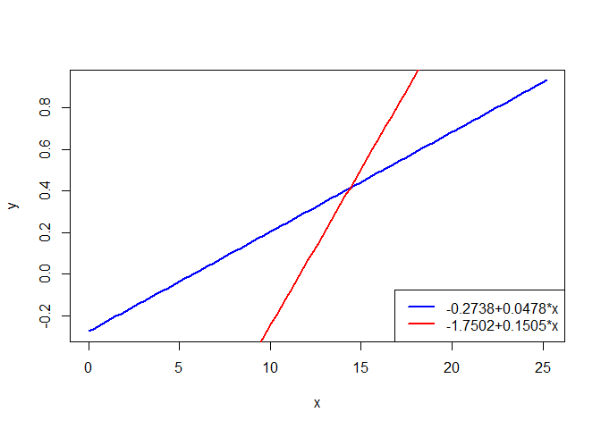

```r
df6=data.frame(year=c(1946:1954),y=c(0.36,0.21,0.08,0.2,0.1,0.12,0.41,0.51,0.43),x=c(8.8,9.4,10,10.6,11,11.9,12.7,13.5,14.3))
df7=data.frame(year=c(1955:1963),y=c(0.59,0.9,0.95,0.82,1.04,1.53,1.94,1.75,1.99),x=c(15.5,16.7,17.7,18.6,19.7,21.1,22.8,23.9,25.2))
model9=lm(y~x,data=df6)
model10=lm(y~x,data=df7)


m1=paste0(round(coef(model9)[1],4),'+',round(coef(model9)[2],4),'*x')
m2=paste0(round(coef(model10)[1],4),'+',round(coef(model10)[2],4),'*x')

curve(coef(model9)[1] + coef(model9)[2] *x ,from=0, to=max(df6$x,df7$x) ,col='blue', lwd=2 ,ylab='y')
curve( coef(model10)[1] + coef(model10)[2] *x,add = TRUE, col='red', lwd=2 )
legend(x = "bottomright",          # Position
       legend = c(m1, m2),  # Legend texts
       lty = c(1, 1),           # Line types
       col = c('blue', 'red'),           # Line colors
       lwd = 2,                  # Line width
       )
```

```r
library('gap')
knitr::kable(chow.test(df6$y, df6$x, df7$y, df7$x))
```

|  | x |
| --- | --- |
| F value | 4.9384378 |
| d.f.1 | 2.0000000 |
| d.f.2 | 14.0000000 |
| P value | 0.0238261 |

It can be seen that the F value and $P-value$ are equal to $4.9384$ and $0.0238$, respectively, meaning the $H_0$ Hypothesis cannot be accepted.